# Topic Geostatistical data

Georgios Karagiannis

2024-11-29

# Question set II: Geostatistics

## Question

What is the main purpose of a semivariogram in geostatistics?

[_] To determine the relationship between two variables

[X] To measure the spatial dependence of a variable

[_] To cluster data points

[_] To test hypotheses

## Question

[_] The nugget effect in a semivariogram represents

[_] Long-range spatial dependence

[_] The value on the vertical axis of a semivariogram model where the model levels out at a certain distance.

[X] Pure random error or measurement error

[_] The range of spatial autocorrelation

## Univariate Geostatistics

Consider the scallop data set which is based on a 1990 survey cruise in the Atlantic continental shelf off Long Island, New York, U.S.A.

Download the dataset by running the script

```r
rm(list=ls())

scallop.mod <- read.csv('https://raw.githubusercontent.com/georgios-stats/Spatio-Temporal_Statistics_Michaelmas_2024/refs/heads/main/Misc/scallop.mod.csv',sep=',')

print(scallop.mod)
```

```
##       X latitude longitude tot.catch log.1.p.tot.catch
## 1     1 40.55000 -71.55000         0         0.0000000
## 2     2 40.46667 -71.51667         0         0.0000000
## 3     3 40.51667 -71.71667         0         0.0000000
## 4     4 40.38333 -71.85000         1         0.6931472
## 5     5 40.31667 -71.78333         0         0.0000000
## 6     6 40.26667 -71.88333         0         0.0000000
## 7     7 40.13333 -72.08333         2         1.0986123
## 8     8 40.06667 -72.16667         0         0.0000000
## 9     9 40.10000 -72.31667         7         2.0794415
## 10   10 40.01667 -72.40000        13         2.6390573
## 11   11 39.90000 -72.56667       530         6.2747620
## 12   12 39.81667 -72.48333      2750         7.9197198
## 13   13 39.85000 -72.58333      2060         7.6309466
## 14   14 39.81667 -72.68333      1016         6.9246124
```

[output cut: 134 more lines]

This data set contains the following columns:

- latitude degrees latitude (north of the Equator).
- longitude degrees longitude (west of Greenwich).
- tot.catch size of scallop catch at location specified by “latitude” and “longitude”
- log.1.p.tot.catch is the log scallop catch size resulted via the transformation
  $$log.1.p.tot.catch = \log( 1.0 + tot.catch )$$

Consider as quantity of interest the log scallop catch size (log.1.p.tot.catch) whose spatial dependence we wish to investigate.

```r
rm(list=ls())
scallop.mod <- read.csv('https://raw.githubusercontent.com/georgios-stats/Spatio-Temporal_Statistics_Michaelmas_2024/refs/heads/main/Misc/scallop.mod.csv',sep=',')
print(scallop.mod)
```

```
##       X latitude longitude tot.catch log.1.p.tot.catch
## 1     1 40.55000 -71.55000         0         0.0000000
## 2     2 40.46667 -71.51667         0         0.0000000
## 3     3 40.51667 -71.71667         0         0.0000000
## 4     4 40.38333 -71.85000         1         0.6931472
## 5     5 40.31667 -71.78333         0         0.0000000
## 6     6 40.26667 -71.88333         0         0.0000000
## 7     7 40.13333 -72.08333         2         1.0986123
## 8     8 40.06667 -72.16667         0         0.0000000
## 9     9 40.10000 -72.31667         7         2.0794415
## 10   10 40.01667 -72.40000        13         2.6390573
## 11   11 39.90000 -72.56667       530         6.2747620
## 12   12 39.81667 -72.48333      2750         7.9197198
## 13   13 39.85000 -72.58333      2060         7.6309466
## 14   14 39.81667 -72.68333      1016         6.9246124
```

[output cut: 134 more lines]

Consider the geostatistical model where the log scallop catch size is modeled an intrinsic random field $\left(Z\left(s\right);s\in\mathcal{S}\right)$ with

$$\begin{equation}
Z\left(s\right)=\mu\left(s\right)+\delta\left(s\right)\label{eq:-39}
\end{equation}$$

where $\mu\left(s\right)=\beta_{0}$ is an unknown constant drift, $\delta\left(s\right)$ is an intrinsic random field, and $s=(s_1,s_2)$ denotes the spatial coordinates longitude and latitude.

## Problem: Spatial dependency

Draw a plot presenting the semivariogram cloud using the default options by R.

In the following questions, you will be asked to upload the plot and the code used to derive the plot.

### Question

Upload the produced plot of the semivariogram cloud below.

- See below

### Question

Copy and paste the code you wrote to produce the plot above.

```r
rm(list=ls())
# load data
scallop.mod <- read.csv('https://raw.githubusercontent.com/georgios-stats/Spatio-Temporal_Statistics_Michaelmas_2024/refs/heads/main/Misc/scallop.mod.csv',sep=',')
scallop.mod.df <- as.data.frame(scallop.mod)
library(sp)
library(sf)
```

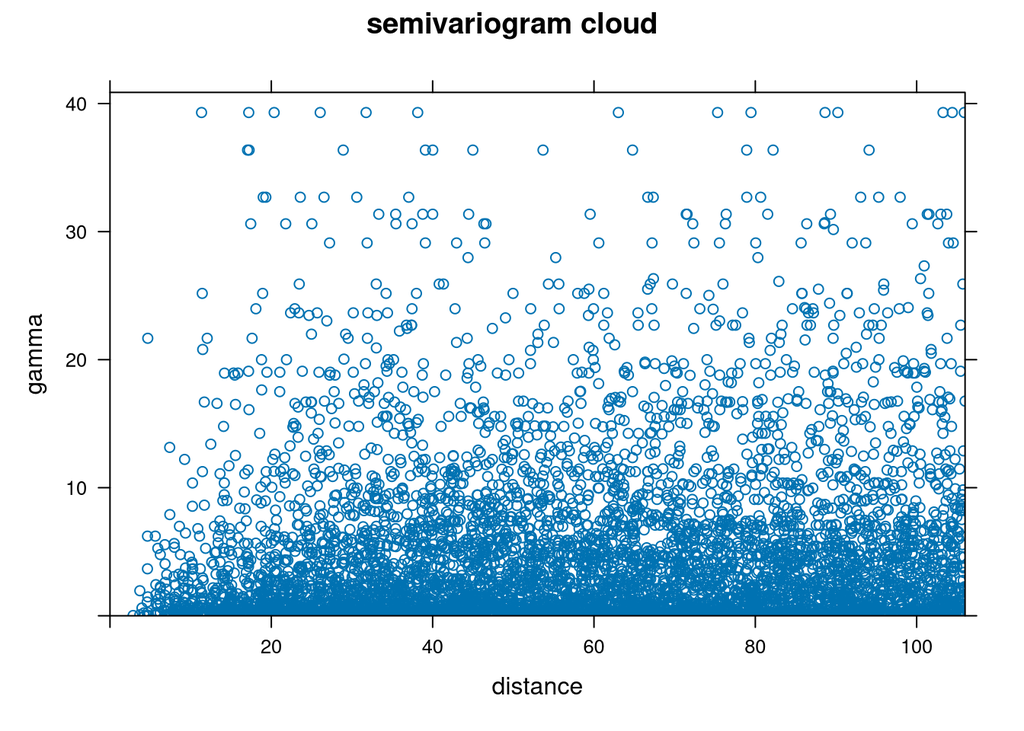

```r
scallop.mod.map <- st_as_sf(scallop.mod.df,
                         coords = c("longitude", "latitude"),
                         crs = 4326
                        )
scallop.mod.map$longitude <-  scallop.mod.df$longitude
scallop.mod.map$latitude <-  scallop.mod.df$latitude
# Compute the sample variogram cloud
library(gstat)
frml <- log.1.p.tot.catch ~ 1
scallop.mod.map.cld <- variogram(object = frml,
                                 data = scallop.mod.map,
                                 cloud = TRUE
                                 )
# plot it
plot(scallop.mod.map.cld,
      xlab = 'distance',
      ylab = 'gamma',
      main = 'semivariogram cloud'
)
```

```r
png('./non-par-semivar.png')
plot(scallop.mod.map.cld,
      xlab = 'distance',
      ylab = 'gamma',
      main = 'semivariogram cloud'
)
dev.off()
```

## Problem: Spatial dependency

Consider the scallop data set .

Consider a parametric semivariogram with mathematical formula

$$\gamma\left(h;\theta\right)=\gamma_{\text{nugget}}\left(h;\sigma_{\text{nugget}}^{2}\right)+\gamma_{\text{spherical}}\left(h;\sigma_{\text{spherical}}^{2},\phi_{\text{spherical}}\right)$$
$\theta=\left(\sigma_{\text{nugget}}^{2},\sigma_{\text{spherical}}^{2},\phi_{\text{spherical}}\right)^{\top}$ where $\gamma_{\text{nugget}}\left(h\right)=\sigma_{\text{nugget}}^{2}1\left( | h| =0\right)$ is the nugget semivariogram with parameter $\sigma_{\text{nugget}}^{2}$, and
$$\gamma_{\text{spherical}}\left(h;\sigma_{\text{spherical}}^{2},\phi_{\text{spherical}}\right)=\sigma_{\text{spherical}}^{2}\left(\frac{3}{2}\frac{|
h| _{1}}{\phi_{\text{spherical}}}-\frac{1}{2}\left(\frac{| h|
_{1}}{\phi_{\text{spherical}}}\right)^{3}\right)\text{1}\left( | h|
_{1}<\phi_{\text{spherical}}\right)$$
is the spherical semivariogram with parameters $\sigma_{\text{spherical}}^{2}$ and $\phi_{\text{spherical}}$.

Fit parametric semivariogram $\gamma\left(h;\theta\right)$ against the data set.

In the next questions you will be asked to insert output from this fitting.

### Question

Insert the estimate for $\sigma_{\text{nugget}}^{2}$

- See the output of the code below.

### Question

Insert the estimate for $\sigma_{\text{spherical}}^{2}$

- See the output of the code below.

### Question

Insert the estimate for $\phi_{\text{spherical}}^{2}$

- See the output of the code below.

### Question

Create a plot for the fitted parametric semivariogram with cutoff value equal to 50.

### Question

Copy and paste the code you created to produce the results.

```r
rm(list=ls())
# 0 load data
scallop.mod <- read.csv('https://raw.githubusercontent.com/georgios-stats/Spatio-Temporal_Statistics_Michaelmas_2024/refs/heads/main/Misc/scallop.mod.csv',sep=',')
scallop.mod.df <- as.data.frame(scallop.mod)
library(sp)
library(sf)
scallop.mod.map <- st_as_sf(scallop.mod.df,
                         coords = c("longitude", "latitude"),
                         crs = 4326
                        )
scallop.mod.map$longitude <-  scallop.mod.df$longitude
scallop.mod.map$latitude <-  scallop.mod.df$latitude
# 1 Specify the semi variogram model
library(gstat)
frml <- log.1.p.tot.catch ~ 1
smpl.vgm <- variogram(object = frml,
                      data = scallop.mod.map
                      )
vgm.obj <- vgm(psill = 0.5,
                model = "Nug",
                range = 0
                )
vgm.obj <- vgm(psill = 1,
                 model = "Sph",
                 range = 100,
                 add.to = vgm.obj
                )
# 2 Fit the semi variogram model against the sample variogram
est.vgm <- fit.variogram(object = smpl.vgm,
                         model = vgm.obj
                         )
# 3 Print the estimated values for the parameters of the semi variogram model
print(est.vgm)
```

```
##   model     psill    range
## 1   Nug 0.8428347  0.00000
## 2   Sph 3.8066333 37.49615
```

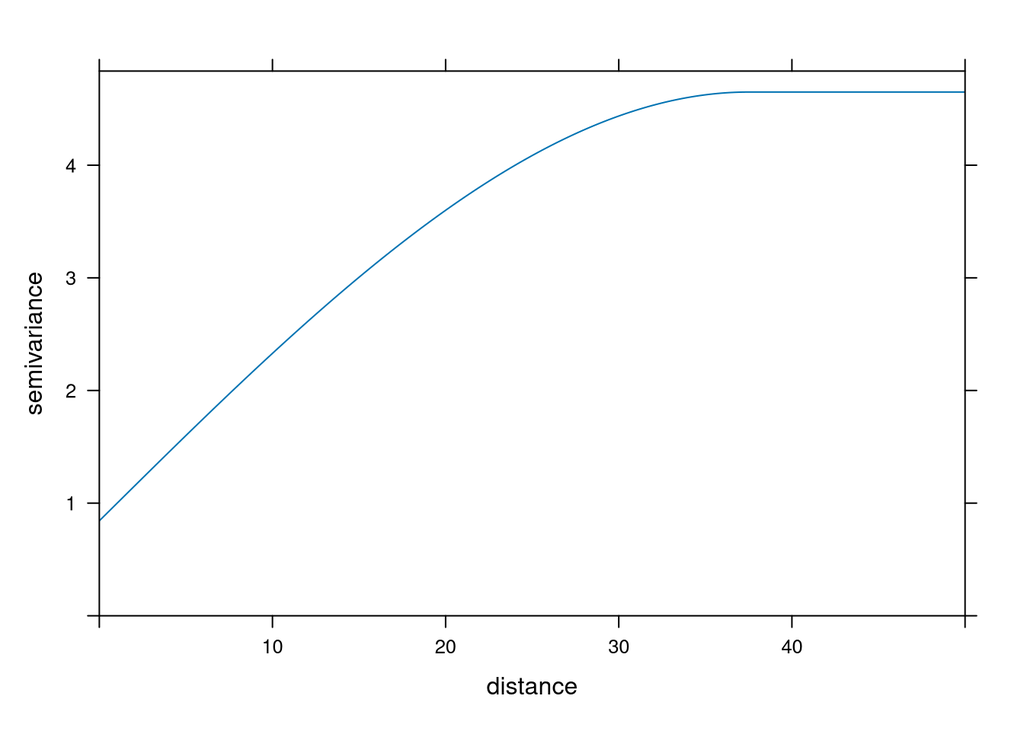

```r
# 4 plot it
plot(est.vgm,
     cutoff = 50)
```

```r
png("./fitted-semivariogram-scallop.mod.png")
plot(est.vgm,
     cutoff = 50)
dev.off()
```

## Problem: Prediction

Consider the scallop data set .

Consider a parametric semivariogram with mathematical formula

$$\gamma\left(h;\theta\right)=\gamma_{\text{nugget}}\left(h;\sigma_{\text{nugget}}^{2}\right)+\gamma_{\text{spherical}}\left(h;\sigma_{\text{spherical}}^{2},\phi_{\text{spherical}}\right)$$
as defined above.

Compute the predictive value and its variance at the unseen location point $s=(-73.7, 38.6)$ by using an appropriate Kriging approach.

In the next questions, you will be asked to insert these values as well as upload the code used to produced them.

### Question

Insert the predictive value of the log scallop catch size $Z(s)$ at $s=(-73.7, 38.6)$ below.

- See theoutput of the code below.

### Question

Insert the variance of the prediction of the log scallop catch size $Z(s)$ at $s=(-73.7, 38.6)$ below.

- See theoutput of the code below.

### Question

Upload the code you created to produce this prediction.

```r
rm(list=ls())
# 0 load data
scallop.mod <- read.csv('https://raw.githubusercontent.com/georgios-stats/Spatio-Temporal_Statistics_Michaelmas_2024/refs/heads/main/Misc/scallop.mod.csv',sep=',')
scallop.mod.df <- as.data.frame(scallop.mod)
library(sp)
library(sf)
scallop.mod.map <- st_as_sf(scallop.mod.df,
                         coords = c("longitude", "latitude"),
                         crs = 4326
                        )
scallop.mod.map$longitude <-  scallop.mod.df$longitude
scallop.mod.map$latitude <-  scallop.mod.df$latitude
# 1 Specify the semi variogram model
frml <- log.1.p.tot.catch ~ 1
smpl.vgm <- variogram(object = frml,
                      data = scallop.mod.map
                      )
vgm.obj <- vgm(psill = 0.5,
                model = "Nug",
                range = 0
                )
vgm.obj <- vgm(psill = 1,
                 model = "Sph",
                 range = 100,
                 add.to = vgm.obj
                )
# 2 Fit the semi variogram model against the sample variogram
est.vgm <- fit.variogram(object = smpl.vgm,
                         model = vgm.obj
                         )
# 3 Train the model
krige.fit <- gstat( formula = frml,
                    data = scallop.mod.map,
                    model = est.vgm
                )
# 4. predict

scallop.mod.new.df <- data.frame(longitude = c(-73.7),
                              latitude = c(38.6)
                              )
scallop.mod.new.sf <- st_as_sf(scallop.mod.new.df,
                                coords = c("longitude", "latitude"),
                                crs = 4326
                                )
krige.prd <- predict(object = krige.fit,
                     newdata = scallop.mod.new.sf
                     )
```

```
## [using ordinary kriging]
```

```r
krige.prd
```

```
## Simple feature collection with 1 feature and 2 fields
## Geometry type: POINT
## Dimension:     XY
## Bounding box:  xmin: -73.7 ymin: 38.6 xmax: -73.7 ymax: 38.6
## Geodetic CRS:  WGS 84
##   var1.pred var1.var           geometry
## 1  4.486442 3.670088 POINT (-73.7 38.6)
```